# cel

```python
import io
import numpy as np
import pandas as pd
import matplotlib.pyplot as plt
import seaborn as sns
data = pd.read_csv('simcel.csv')
data
```

|  | Item_Identifier | Item_Weight | Item_Fat_Content | Item_Visibility | Item_Type | Item_MRP | Outlet_Identifier | Outlet_Establishment_Year | Outlet_Size | Outlet_Location_Type | Outlet_Type | Item_Outlet_Sales |
| --- | --- | --- | --- | --- | --- | --- | --- | --- | --- | --- | --- | --- |
| 0 | FDA15 | 9.300 | Low Fat | 0.016047 | Dairy | 249.8092 | OUT049 | 1999 | Medium | Tier 1 | Supermarket Type1 | 3735.1380 |
| 1 | DRC01 | 5.920 | Regular | 0.019278 | Soft Drinks | 48.2692 | OUT018 | 2009 | Medium | Tier 3 | Supermarket Type2 | 443.4228 |
| 2 | FDN15 | 17.500 | Low Fat | 0.016760 | Meat | 141.6180 | OUT049 | 1999 | Medium | Tier 1 | Supermarket Type1 | 2097.2700 |
| 3 | FDX07 | 19.200 | Regular | 0.000000 | Fruits and Vegetables | 182.0950 | OUT010 | 1998 | NaN | Tier 3 | Grocery Store | 732.3800 |
| 4 | NCD19 | 8.930 | Low Fat | 0.000000 | Household | 53.8614 | OUT013 | 1987 | High | Tier 3 | Supermarket Type1 | 994.7052 |
| ... | ... | ... | ... | ... | ... | ... | ... | ... | ... | ... | ... | ... |
| 8518 | FDF22 | 6.865 | Low Fat | 0.056783 | Snack Foods | 214.5218 | OUT013 | 1987 | High | Tier 3 | Supermarket Type1 | 2778.3834 |
| 8519 | FDS36 | 8.380 | Regular | 0.046982 | Baking Goods | 108.1570 | OUT045 | 2002 | NaN | Tier 2 | Supermarket Type1 | 549.2850 |
| 8520 | NCJ29 | 10.600 | Low Fat | 0.035186 | Health and Hygiene | 85.1224 | OUT035 | 2004 | Small | Tier 2 | Supermarket Type1 | 1193.1136 |
| 8521 | FDN46 | 7.210 | Regular | 0.145221 | Snack Foods | 103.1332 | OUT018 | 2009 | Medium | Tier 3 | Supermarket Type2 | 1845.5976 |
| 8522 | DRG01 | 14.800 | Low Fat | 0.044878 | Soft Drinks | 75.4670 | OUT046 | 1997 | Small | Tier 1 | Supermarket Type1 | 765.6700 |

8523 rows × 12 columns

- Focusing on analysis on non-null columns

```python
data.info(verbose=True, null_counts=True)
```

```
<class 'pandas.core.frame.DataFrame'>
RangeIndex: 8523 entries, 0 to 8522
Data columns (total 12 columns):
 #   Column                     Non-Null Count  Dtype
---  ------                     --------------  -----
 0   Item_Identifier            8523 non-null   object
 1   Item_Weight                7060 non-null   float64
 2   Item_Fat_Content           8523 non-null   object
 3   Item_Visibility            8523 non-null   float64
 4   Item_Type                  8523 non-null   object
 5   Item_MRP                   8523 non-null   float64
 6   Outlet_Identifier          8523 non-null   object
 7   Outlet_Establishment_Year  8523 non-null   int64
 8   Outlet_Size                6113 non-null   object
 9   Outlet_Location_Type       8523 non-null   object
 10  Outlet_Type                8523 non-null   object
 11  Item_Outlet_Sales          8523 non-null   float64
dtypes: float64(4), int64(1), object(7)
memory usage: 799.2+ KB
```

- Check distinct values from categorical columns to see if it looks normal

```python
for i in data.columns:
    print("COLUMN " + i)
    print(data[i].unique())
    print('*-------------------------------------')
```

```
COLUMN Item_Identifier
['FDA15' 'DRC01' 'FDN15' ... 'NCF55' 'NCW30' 'NCW05']
*-------------------------------------
COLUMN Item_Weight
[ 9.3    5.92  17.5   19.2    8.93  10.395 13.65     nan 16.2   11.8
 18.5   15.1   17.6   16.35   9.    13.35  18.85  14.6   13.85  13.
  7.645 11.65   5.925 19.25  18.6   18.7   17.85  10.     8.85   9.8
 13.6   21.35  12.15   6.42  19.6   15.85   7.39  10.195  9.895 10.895
  7.905  9.195  8.365  7.97  17.7   19.35   8.645 15.6   18.25   7.855
  7.825  8.39  12.85  19.     5.905  7.76  16.75  15.5    6.055  6.305
 20.85  20.75   8.895 19.7    8.75  13.3    8.31  19.75  17.1   10.5
  6.635 14.15   8.89   9.1    7.5   16.85   7.485 11.6   12.65  20.25
  8.6   12.6    8.88  20.5   13.5    7.235  6.92   8.02  12.8   16.6
 14.    16.    21.25   7.365 18.35   5.465  7.27   6.155 19.5   15.2
 14.5   13.1   12.3   11.1   11.3    5.75  11.35   6.525 10.3    5.78
 11.85  18.75   5.26  16.1    9.5   13.8   14.65   6.67   6.11  17.2
  6.32   4.88   5.425 14.1    7.55  17.25  12.    10.1    7.785 13.15
  8.5    7.63   9.285  7.975 15.7    8.985 20.35   6.59  19.85   6.26
 18.2    8.695  7.075  8.195  7.09   6.095  6.15   9.395 15.75   7.475
  6.445 19.1   15.    16.7    7.07   6.48   9.695 11.15   9.6   20.7
  5.5    7.895 17.35   7.285  6.17  11.395  7.71  12.1   14.35   8.1
  8.05  16.5    6.785  7.575  7.47  15.25   7.605 18.    21.2    8.97
 10.6    6.865 10.8   15.15  18.1    6.655 20.1    7.935 15.35  12.35
  6.85   8.775 14.85   7.84  12.5    8.325  5.765  5.985 14.3    6.135
  8.51   6.65   5.695  6.36   8.3    7.56   8.71   6.695 14.8   17.75
  8.575  6.57   8.68   5.63   9.13   6.715  5.82   7.93   5.     7.445
  6.675  8.18   6.98   7.435 20.6    8.355  8.975 20.2    5.655  5.175
 20.     7.67   4.785  8.395  6.175  8.21   5.845  7.17   8.785  7.89
  5.32   5.03   8.945  6.28   7.565  9.31   7.02   5.46   6.13   6.55
 17.    16.25   5.15   7.865  6.575  7.06   5.785  7.42   6.235  6.75
  5.86   5.035  6.38   5.675 11.5   21.    21.1    4.61   7.     6.405
 14.7    7.68   8.185  8.655 10.85   8.42   7.85   4.59   7.51  11.
  6.71  14.75   7.59   5.155  6.365  8.235  5.365  8.485  7.535  4.92
  6.385  8.26   7.945  8.63   9.21   6.965  8.905  7.21   7.3    9.27
 10.695  6.215  7.405  7.72   6.115  6.035  6.78  15.3    7.105  7.52
  4.805  6.425  7.6    6.61   7.325  8.115  5.94   5.635  7.35   5.825
  6.63   7.05   8.315  6.8    7.035  8.96   5.51   8.43   8.27   7.81
  6.885  5.44   5.405  4.635 10.65   5.735  6.465  8.84   7.75   6.765
  9.065  7.655  4.615  8.76   7.1    6.195  5.615  8.52   7.26   6.825
  5.325  5.59   5.88   5.19   6.985  9.06   6.69   8.615  7.275  6.96
```

[output cut: 27 more lines]

```
[1999 2009 1998 1987 1985 2002 2007 1997 2004]
*-------------------------------------
COLUMN Outlet_Size
['Medium' nan 'High' 'Small']
*-------------------------------------
COLUMN Outlet_Location_Type
['Tier 1' 'Tier 3' 'Tier 2']
*-------------------------------------
COLUMN Outlet_Type
['Supermarket Type1' 'Supermarket Type2' 'Grocery Store'
 'Supermarket Type3']
*-------------------------------------
COLUMN Item_Outlet_Sales
[3735.138   443.4228 2097.27   ... 7182.6504 3608.636  2778.3834]
*-------------------------------------
```

- needs to clean column item_fat_content

```python
def fat_process(x):
    if x in ['low fat','LF']:
        return 'Low Fat'
    if x == 'reg':
        return 'Regular'
    else:
        return x

data['Item_Fat_Content'] = data['Item_Fat_Content'].apply(fat_process)
```

- The majority of outlet type are supermarket type 1, located in tier 1 location and tier 2

```python
print(data.groupby(['Outlet_Type']).Outlet_Identifier.nunique())

print('----------***********----------')
print(data[data['Outlet_Type'] == 'Supermarket Type1'].groupby(['Outlet_Location_Type']).Outlet_Identifier.nunique())
```

```
Outlet_Type
Grocery Store        2
Supermarket Type1    6
Supermarket Type2    1
Supermarket Type3    1
Name: Outlet_Identifier, dtype: int64
----------***********----------
Outlet_Location_Type
Tier 1    2
Tier 2    3
Tier 3    1
Name: Outlet_Identifier, dtype: int64
```

```
(array([], dtype=float64), [])
```

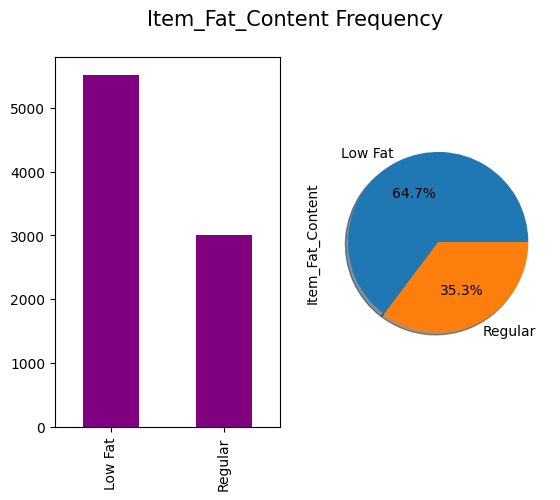

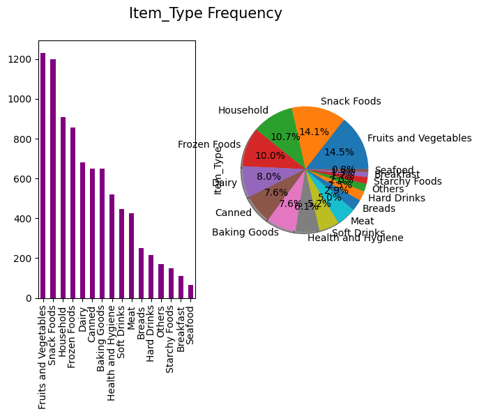

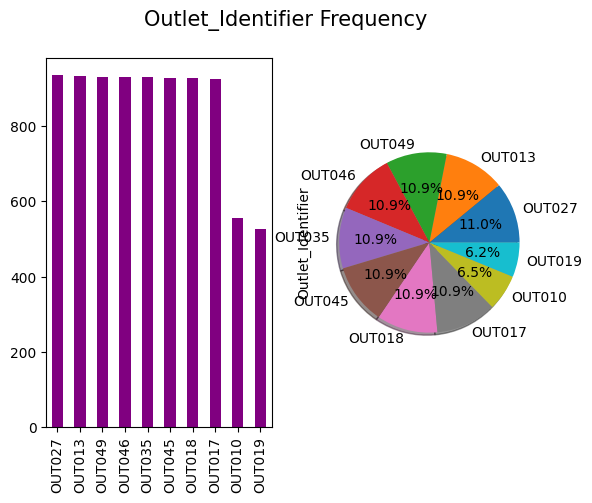

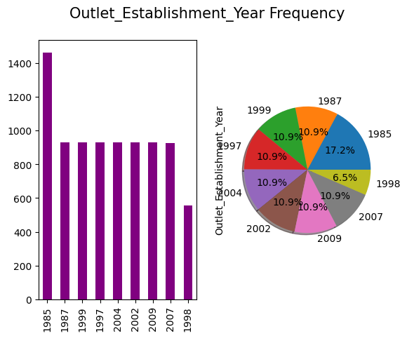

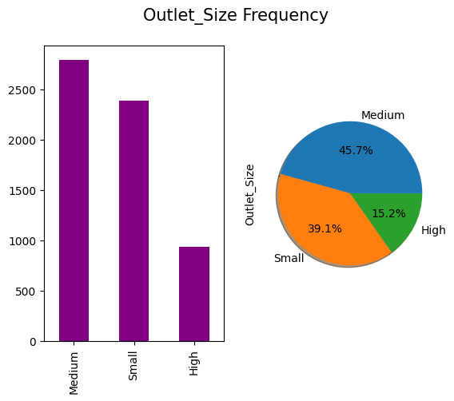

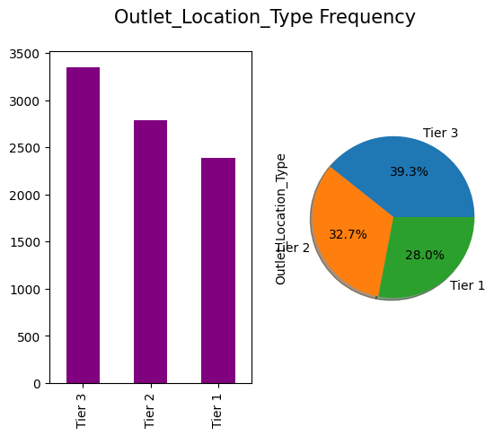

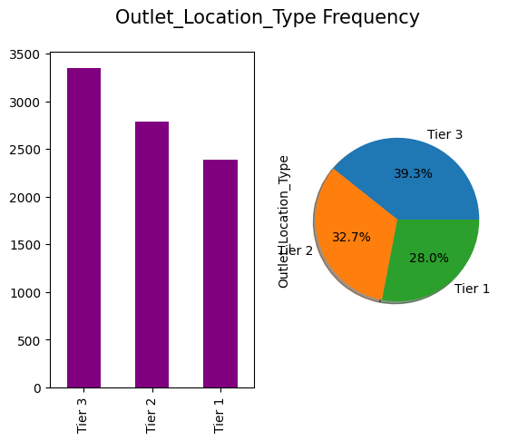

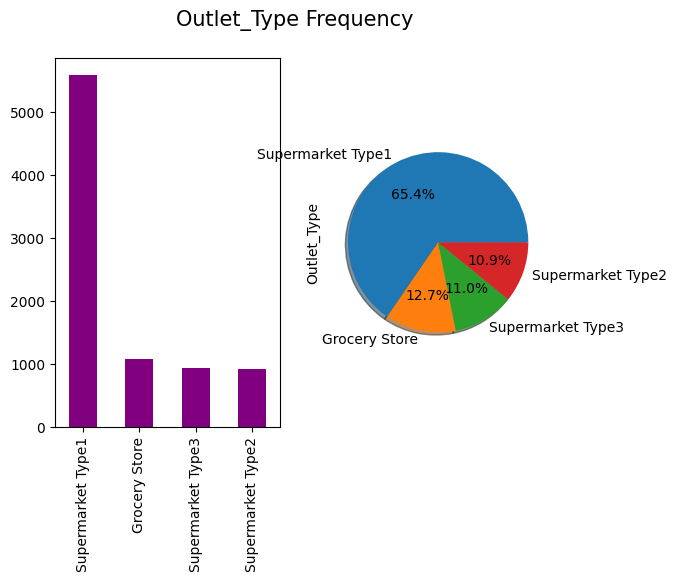

```python
fig, ax = plt.subplots(1, 2)
data["Item_Fat_Content"].value_counts().plot.bar(color="purple", ax=ax[0])
data["Item_Fat_Content"].value_counts().plot.pie(autopct='%1.1f%%',shadow=True,textprops={"fontsize": 10},ax=ax[1])
fig.suptitle("Item_Fat_Content Frequency", fontsize=15)
plt.xticks(rotation=90)
plt.yticks(rotation=45)

fig, ax = plt.subplots(1, 2)
data["Item_Type"].value_counts().plot.bar(color="purple", ax=ax[0])
data["Item_Type"].value_counts().plot.pie(autopct='%1.1f%%',shadow=True,textprops={"fontsize": 10},ax=ax[1])
fig.suptitle("Item_Type Frequency", fontsize=15)
plt.xticks(rotation=90)
plt.yticks(rotation=45)

fig, ax = plt.subplots(1, 2)
data["Outlet_Identifier"].value_counts().plot.bar(color="purple", ax=ax[0])
data["Outlet_Identifier"].value_counts().plot.pie(autopct='%1.1f%%',shadow=True,textprops={"fontsize": 10},ax=ax[1])
fig.suptitle("Outlet_Identifier Frequency", fontsize=15)
plt.xticks(rotation=90)
plt.yticks(rotation=45)


fig, ax = plt.subplots(1, 2)
data["Outlet_Establishment_Year"].value_counts().plot.bar(color="purple", ax=ax[0])
data["Outlet_Establishment_Year"].value_counts().plot.pie(autopct='%1.1f%%',shadow=True,textprops={"fontsize": 10},ax=ax[1])
fig.suptitle("Outlet_Establishment_Year Frequency", fontsize=15)
plt.xticks(rotation=90)
plt.yticks(rotation=45)


fig, ax = plt.subplots(1, 2)
data["Outlet_Size"].value_counts().plot.bar(color="purple", ax=ax[0])
data["Outlet_Size"].value_counts().plot.pie(autopct='%1.1f%%',shadow=True,textprops={"fontsize": 10},ax=ax[1])
fig.suptitle("Outlet_Size Frequency", fontsize=15)
plt.xticks(rotation=90)
plt.yticks(rotation=45)

fig, ax = plt.subplots(1, 2)
data["Outlet_Location_Type"].value_counts().plot.bar(color="purple", ax=ax[0])
data["Outlet_Location_Type"].value_counts().plot.pie(autopct='%1.1f%%',shadow=True,textprops={"fontsize": 10},ax=ax[1])
fig.suptitle("Outlet_Location_Type Frequency", fontsize=15)
plt.xticks(rotation=90)
plt.yticks(rotation=45)



fig, ax = plt.subplots(1, 2)
data["Outlet_Location_Type"].value_counts().plot.bar(color="purple", ax=ax[0])
data["Outlet_Location_Type"].value_counts().plot.pie(autopct='%1.1f%%',shadow=True,textprops={"fontsize": 10},ax=ax[1])
fig.suptitle("Outlet_Location_Type Frequency", fontsize=15)
plt.xticks(rotation=90)
plt.yticks(rotation=45)



fig, ax = plt.subplots(1, 2)
data["Outlet_Type"].value_counts().plot.bar(color="purple", ax=ax[0])
data["Outlet_Type"].value_counts().plot.pie(autopct='%1.1f%%',shadow=True,textprops={"fontsize": 10},ax=ax[1])
fig.suptitle("Outlet_Type Frequency", fontsize=15)
plt.xticks(rotation=90)
plt.yticks(rotation=45)
```

**Item type sale by each outlet type**

- Sales from all 4 outlet are led by fruits & vegetables and snack foods. People tend to buy snack food more from grocery store and supermarket type 2. Overall, it seems like the spending pattern is identical for all customers from this outlet
- Seafood, Starchy food, Breakfast and non-categorized items account for the least sales in all 4 outlets
- Looking at all food items ( where item types are not household, health & hygenie or others) , sales from all 4 outlet types share a similar patterns between lowfat content and regular fat content. Low fat content food make up for roughly 10% greater sales revenue compared to regular fat content food. Seems like the health concerns spread across buyers from all walks of life

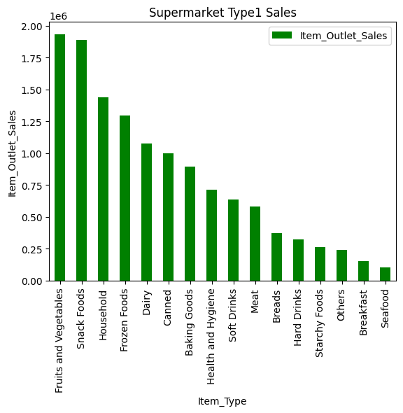

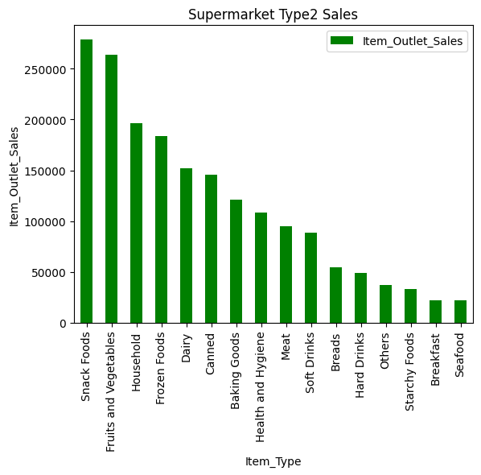

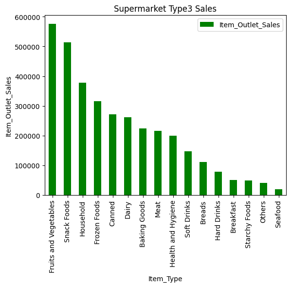

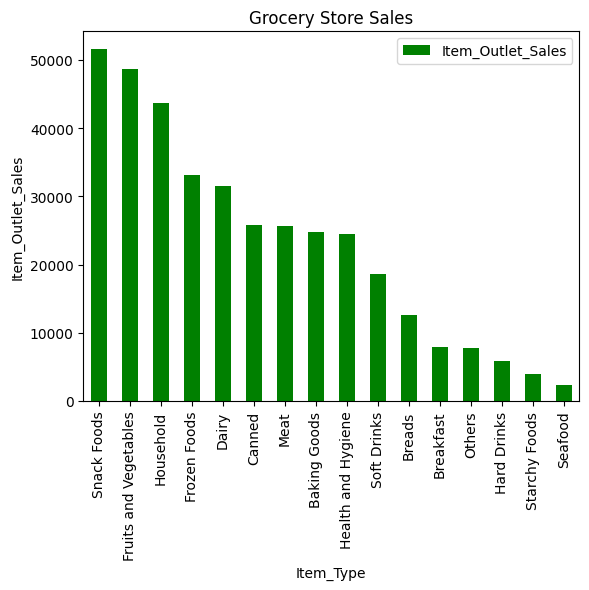

```python
dr = data[data['Outlet_Type'] == 'Supermarket Type1'].groupby(['Item_Type']).sum()['Item_Outlet_Sales'].reset_index()
dr.sort_values('Item_Outlet_Sales',ascending = False).plot(kind='bar', x='Item_Type', y='Item_Outlet_Sales', color='green')
plt.title('Supermarket Type1 Sales')
plt.xlabel('Item_Type')
plt.ylabel('Item_Outlet_Sales')
plt.show()

dr = data[data['Outlet_Type'] == 'Supermarket Type2'].groupby(['Item_Type']).sum()['Item_Outlet_Sales'].reset_index()
dr.sort_values('Item_Outlet_Sales',ascending = False).plot(kind='bar', x='Item_Type', y='Item_Outlet_Sales', color='green')
plt.title('Supermarket Type2 Sales')
plt.xlabel('Item_Type')
plt.ylabel('Item_Outlet_Sales')
plt.show()


dr = data[data['Outlet_Type'] == 'Supermarket Type3'].groupby(['Item_Type']).sum()['Item_Outlet_Sales'].reset_index()
dr.sort_values('Item_Outlet_Sales',ascending = False).plot(kind='bar', x='Item_Type', y='Item_Outlet_Sales', color='green')
plt.title('Supermarket Type3 Sales')
plt.xlabel('Item_Type')
plt.ylabel('Item_Outlet_Sales')
plt.show()


dr = data[data['Outlet_Type'] == 'Grocery Store'].groupby(['Item_Type']).sum()['Item_Outlet_Sales'].reset_index()
dr.sort_values('Item_Outlet_Sales',ascending = False).plot(kind='bar', x='Item_Type', y='Item_Outlet_Sales', color='green')
plt.title('Grocery Store Sales')
plt.xlabel('Item_Type')
plt.ylabel('Item_Outlet_Sales')
plt.show()
```

```python
print(data[(data['Outlet_Type'] == 'Supermarket Type1') & ~(data['Item_Type'].isin(['Household','Health and Hygiene','Others']))].groupby(['Item_Fat_Content']).sum()['Item_Outlet_Sales'] / data[data['Outlet_Type'] == 'Supermarket Type1'].sum()['Item_Outlet_Sales'])
print(data[(data['Outlet_Type'] == 'Supermarket Type2') & ~(data['Item_Type'].isin(['Household','Health and Hygiene','Others'])) ].groupby(['Item_Fat_Content']).sum()['Item_Outlet_Sales'] / data[data['Outlet_Type'] == 'Supermarket Type2'].sum()['Item_Outlet_Sales'])
print(data[(data['Outlet_Type'] == 'Supermarket Type3') & ~(data['Item_Type'].isin(['Household','Health and Hygiene','Others']))].groupby(['Item_Fat_Content']).sum()['Item_Outlet_Sales'] / data[data['Outlet_Type'] == 'Supermarket Type3'].sum()['Item_Outlet_Sales'])

print(data[(data['Outlet_Type'] == 'Grocery Store') & ~(data['Item_Type'].isin(['Household','Health and Hygiene','Others']))].groupby(['Item_Fat_Content']).sum()['Item_Outlet_Sales'] / data[data['Outlet_Type'] == 'Grocery Store'].sum()['Item_Outlet_Sales'])
```

```
Item_Fat_Content
Low Fat    0.454226
Regular    0.360742
Name: Item_Outlet_Sales, dtype: float64
Item_Fat_Content
Low Fat    0.463932
Regular    0.351285
Name: Item_Outlet_Sales, dtype: float64
Item_Fat_Content
Low Fat    0.459387
Regular    0.361715
Name: Item_Outlet_Sales, dtype: float64
Item_Fat_Content
Low Fat    0.447459
Regular    0.346035
Name: Item_Outlet_Sales, dtype: float64
```

```python
data['SalesOverVisibility'] = data['Item_Outlet_Sales'] / data['Item_Visibility']

data['SalesOverWeight'] = data['Item_Outlet_Sales'] / data['Item_Weight']
```

```python
lj1 = data.groupby(['Item_Type']).max()['SalesOverVisibility'].reset_index()

lj2 = data.groupby(['Item_Type']).max()['SalesOverWeight'].reset_index()
```

```python
data = data.merge(lj1, on = 'Item_Type', how ='left')
data = data.merge(lj2, on = 'Item_Type', how ='left')
```

```python
data[data['SalesOverVisibility_x'] == data['SalesOverVisibility_y']]
```

|  | Item_Identifier | Item_Weight | Item_Fat_Content | Item_Visibility | Item_Type | Item_MRP | Outlet_Identifier | Outlet_Establishment_Year | Outlet_Size | Outlet_Location_Type | Outlet_Type | Item_Outlet_Sales | SalesOverVisibility_x | SalesOverWeight_x | SalesOverVisibility_y | SalesOverWeight_y |
| --- | --- | --- | --- | --- | --- | --- | --- | --- | --- | --- | --- | --- | --- | --- | --- | --- |
| 3 | FDX07 | 19.200 | Regular | 0.0 | Fruits and Vegetables | 182.0950 | OUT010 | 1998 | NaN | Tier 3 | Grocery Store | 732.3800 | inf | 38.144792 | inf | 1088.272845 |
| 4 | NCD19 | 8.930 | Low Fat | 0.0 | Household | 53.8614 | OUT013 | 1987 | High | Tier 3 | Supermarket Type1 | 994.7052 | inf | 111.389160 | inf | 955.398974 |
| 5 | FDP36 | 10.395 | Regular | 0.0 | Baking Goods | 51.4008 | OUT018 | 2009 | Medium | Tier 3 | Supermarket Type2 | 556.6088 | inf | 53.545820 | inf | 967.845854 |
| 10 | FDY07 | 11.800 | Low Fat | 0.0 | Fruits and Vegetables | 45.5402 | OUT049 | 1999 | Medium | Tier 1 | Supermarket Type1 | 1516.0266 | inf | 128.476831 | inf | 1088.272845 |
| 32 | FDP33 | 18.700 | Low Fat | 0.0 | Snack Foods | 256.6672 | OUT018 | 2009 | Medium | Tier 3 | Supermarket Type2 | 3068.0064 | inf | 164.064513 | inf | 1185.999446 |
| ... | ... | ... | ... | ... | ... | ... | ... | ... | ... | ... | ... | ... | ... | ... | ... | ... |
| 8480 | FDQ58 | NaN | Low Fat | 0.0 | Snack Foods | 154.5340 | OUT019 | 1985 | Small | Tier 1 | Grocery Store | 459.4020 | inf | NaN | inf | 1185.999446 |
| 8484 | DRJ49 | 6.865 | Low Fat | 0.0 | Soft Drinks | 129.9652 | OUT013 | 1987 | High | Tier 3 | Supermarket Type1 | 2324.9736 | inf | 338.670590 | inf | 1100.567400 |
| 8486 | FDR20 | 20.000 | Regular | 0.0 | Fruits and Vegetables | 46.4744 | OUT010 | 1998 | NaN | Tier 3 | Grocery Store | 45.2744 | inf | 2.263720 | inf | 1088.272845 |
| 8494 | NCI54 | 15.200 | Low Fat | 0.0 | Household | 110.4912 | OUT017 | 2007 | NaN | Tier 2 | Supermarket Type1 | 1637.8680 | inf | 107.754474 | inf | 955.398974 |
| 8500 | NCQ42 | 20.350 | Low Fat | 0.0 | Household | 125.1678 | OUT017 | 2007 | NaN | Tier 2 | Supermarket Type1 | 1907.5170 | inf | 93.735479 | inf | 955.398974 |

526 rows × 16 columns

```python
data[data['SalesOverWeight_x'] == data['SalesOverWeight_y']]
```

|  | Item_Identifier | Item_Weight | Item_Fat_Content | Item_Visibility | Item_Type | Item_MRP | Outlet_Identifier | Outlet_Establishment_Year | Outlet_Size | Outlet_Location_Type | Outlet_Type | Item_Outlet_Sales | SalesOverVisibility_x | SalesOverWeight_x | SalesOverVisibility_y | SalesOverWeight_y |
| --- | --- | --- | --- | --- | --- | --- | --- | --- | --- | --- | --- | --- | --- | --- | --- | --- |
| 599 | DRK37 | 5.000 | Low Fat | 0.044005 | Soft Drinks | 188.8530 | OUT046 | 1997 | Small | Tier 1 | Supermarket Type1 | 5502.8370 | 1.250512e+05 | 1100.567400 | inf | 1100.567400 |
| 997 | FDK28 | 5.695 | Low Fat | 0.065961 | Frozen Foods | 259.2646 | OUT017 | 2007 | NaN | Tier 2 | Supermarket Type1 | 9275.9256 | 1.406276e+05 | 1628.784126 | inf | 1628.784126 |
| 1750 | NCF06 | 6.235 | Low Fat | 0.020230 | Household | 260.8962 | OUT049 | 1999 | Medium | Tier 1 | Supermarket Type1 | 5956.9126 | 2.944629e+05 | 955.398974 | inf | 955.398974 |
| 2535 | FDD44 | 8.050 | Regular | 0.078844 | Fruits and Vegetables | 257.0646 | OUT017 | 2007 | NaN | Tier 2 | Supermarket Type1 | 8760.5964 | 1.111131e+05 | 1088.272845 | inf | 1088.272845 |
| 2680 | FDV25 | 5.905 | Low Fat | 0.045614 | Canned | 221.5456 | OUT013 | 1987 | High | Tier 3 | Supermarket Type1 | 6852.4136 | 1.502253e+05 | 1160.442608 | inf | 1160.442608 |
| 3087 | DRK23 | 8.395 | Low Fat | 0.071917 | Hard Drinks | 254.8040 | OUT013 | 1987 | High | Tier 3 | Supermarket Type1 | 7843.1240 | 1.090584e+05 | 934.261346 | inf | 934.261346 |
| 3208 | FDZ34 | 6.695 | Low Fat | 0.075864 | Starchy Foods | 192.0820 | OUT035 | 2004 | Small | Tier 2 | Supermarket Type1 | 6757.8700 | 8.907855e+04 | 1009.390590 | inf | 1009.390590 |
| 4289 | NCM05 | 6.825 | Low Fat | 0.059847 | Health and Hygiene | 262.5226 | OUT046 | 1997 | Small | Tier 1 | Supermarket Type1 | 9779.9362 | 1.634157e+05 | 1432.957685 | inf | 1432.957685 |
| 4305 | FDL58 | 5.780 | Regular | 0.074087 | Snack Foods | 264.9568 | OUT013 | 1987 | High | Tier 3 | Supermarket Type1 | 6855.0768 | 9.252693e+04 | 1185.999446 | inf | 1185.999446 |
| 5514 | FDW02 | 4.805 | Regular | 0.037699 | Dairy | 125.5704 | OUT046 | 1997 | Small | Tier 1 | Supermarket Type1 | 3880.2824 | 1.029268e+05 | 807.550968 | inf | 807.550968 |
| 5595 | FDT48 | 4.920 | Low Fat | 0.046142 | Baking Goods | 199.1084 | OUT018 | 2009 | Medium | Tier 3 | Supermarket Type2 | 4761.8016 | 1.031983e+05 | 967.845854 | inf | 967.845854 |
| 6765 | FDO37 | 8.060 | Low Fat | 0.021410 | Breakfast | 229.7326 | OUT049 | 1999 | Medium | Tier 1 | Supermarket Type1 | 6930.9780 | 3.237275e+05 | 859.922829 | inf | 859.922829 |
| 7163 | FDX35 | 5.035 | Regular | 0.000000 | Breads | 228.2036 | OUT046 | 1997 | Small | Tier 1 | Supermarket Type1 | 4781.7756 | inf | 949.707170 | inf | 949.707170 |
| 7726 | FDG33 | 5.365 | Regular | 0.140214 | Seafood | 173.7764 | OUT035 | 2004 | Small | Tier 2 | Supermarket Type1 | 4637.9628 | 3.307780e+04 | 864.485144 | inf | 864.485144 |
| 8161 | FDY39 | 5.305 | Regular | 0.047102 | Meat | 181.8608 | OUT049 | 1999 | Medium | Tier 1 | Supermarket Type1 | 4594.0200 | 9.753383e+04 | 865.979265 | inf | 865.979265 |
| 8340 | NCL31 | 7.390 | Low Fat | 0.120468 | Others | 145.1470 | OUT049 | 1999 | Medium | Tier 1 | Supermarket Type1 | 5296.4390 | 4.396553e+04 | 716.703518 | inf | 716.703518 |